# A challenge for intro data viz

Point size, transparency, and faceting

11/17/2020

I’m co-teaching an introductory coding class called R Data and Visualization (R-DAVIS) at UC Davis. This week, we worked on point size and transparency, and faceting `ggplot()` plots. In the interest of keeping things entertaining, I wanted to create a fun dataset that would allow students to practice plotting across groups in an interesting way. So, I decided to “hide” some fun data in a larger dataset that might be tricky to visualize. Below, you can find a guide on how I generated the data, and how the challenge was posed to students. A raw plot, even with faceting, will appear to be uninteresting:

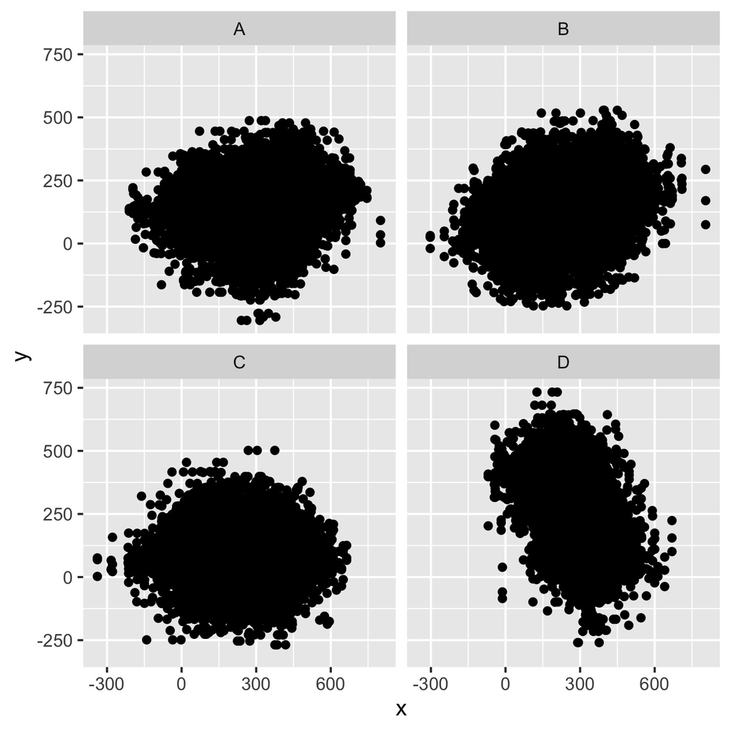

However, if students adjust point size and transparency settings, they will find a hidden shape in each group!

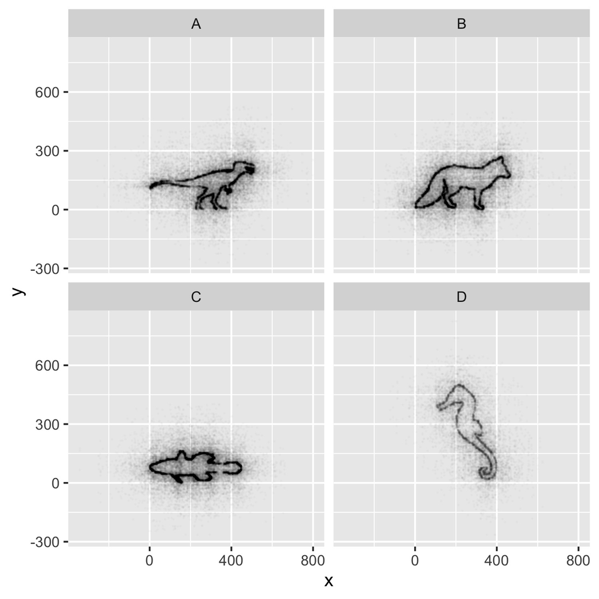

### The setup

This mini-project requires three libraries: `raster::`, `RStoolbox::` and `tidyverse::`. `raster::` lets us import the data, `RStoolbox::` lets us convert imagery to a data.frame, and `tidyverse::` does all the other heavy lifting. Let’s load those.

```r
library(raster)
library(RStoolbox)
library(tidyverse)
```

Let’s start with a few animal silhouettes. I got these from [phylopic](http://phylopic.org/); all images hold no copyright.

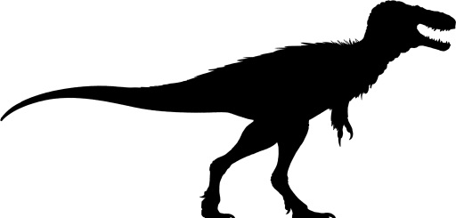

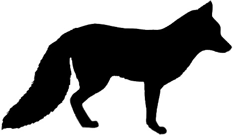

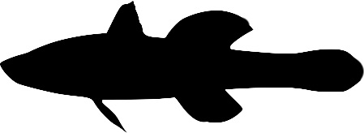

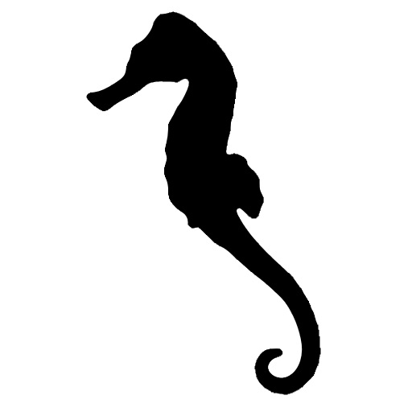

First I’ll import the images as raster datasets:

```r
#### Import data ----
dinoR = raster("data/dino_raw.jpg")
# http://phylopic.org/image/8b28eac0-15fc-4a3d-89c5-a6fcbd141a4a/
foxR = raster("data/fox_raw.jpg")
# http://phylopic.org/image/9c139682-7a9d-44e2-ae90-9be4624c2688/
fishR = raster("data/fish_raw.jpg")
# http://phylopic.org/image/6cf73e55-4e10-47ad-9b7e-33645536863f/
seahR = raster("data/seahorse_raw.jpg")
```

Next, for the data wrangling. It’s a decent-sized chunk of code so it’s collapsed for visual purposes but you can open with the box.

**Data wrangling**

```r
## Fortify
dinoF = fortify(dinoR)
foxF = fortify(foxR)
fishF = fortify(fishR)
seahF = fortify(seahR)

## Add group column
dinoF = dinoF %>%
  rename(Presence = dino_raw) %>%
  add_column(Group = "A")
foxF = foxF %>%
  rename(Presence = fox_raw) %>%
  add_column(Group = "B")
fishF = fishF %>%
  rename(Presence = fish_raw) %>%
  add_column(Group = "C")
seahF = seahF %>%
  rename(Presence = seahorse_raw) %>%
  add_column(Group = "D")

## Combine to single dataset
mydata = do.call("rbind",
                 list(dinoF,
                      foxF,
                      fishF,
                      seahF)) %>%
  filter(Presence != 255,
         Presence > 2)

## Generate several orders of random noise for masking data
mynoise = mydata %>%
  mutate(x2 = x + rnorm(nrow(mydata), 0, 10),
         y2 = y + rnorm(nrow(mydata), 0, 10),
         x3 = x + rnorm(nrow(mydata), 0, 50),
         y3 = y + rnorm(nrow(mydata), 0, 50),
         x4 = x + rnorm(nrow(mydata), 0, 100),
         y4 = y + rnorm(nrow(mydata), 0, 100)) %>%
  select(-x, -y) %>%
  pivot_longer(cols = c(x2,x3,x4),
               names_to = "axis1", values_to = "x") %>%
  pivot_longer(cols = c(y2,y3,y4),
               names_to = "axis2", values_to = "y") %>%
  select(-axis1, -axis2, Presence)


## Combine noise and a strong signature of "true" data
fullData = rbind(mydata, mydata, mydata, mydata, mynoise)
```

Don’t forget to save the data product! That `data.frame()`, after all, forms the core of the challenge for students.

```r
write.table(x = fullData,
            file = "data/mysteryData.csv",
            row.names = FALSE,
            col.names = TRUE,
            sep = ",")
```

### The challenge

You are looking at a new dataset shared with you by a collaborator. You received the dataset shortly after the vernal equinox. Your collaborator didn’t really give you any context on what the data represent, and you need to do some preliminary visualizations before you can really even formulate a question for them. Import the mystery dataset using:

```r
mystery <- read_csv("data/mysteryData.csv")
```

Can you figure out what this dataset represents?  
Hint Use your new knowledge of faceting to break up the data into groups, and consider changing the size and transparency of your geom_’s to get a better look!

**ANSWER**

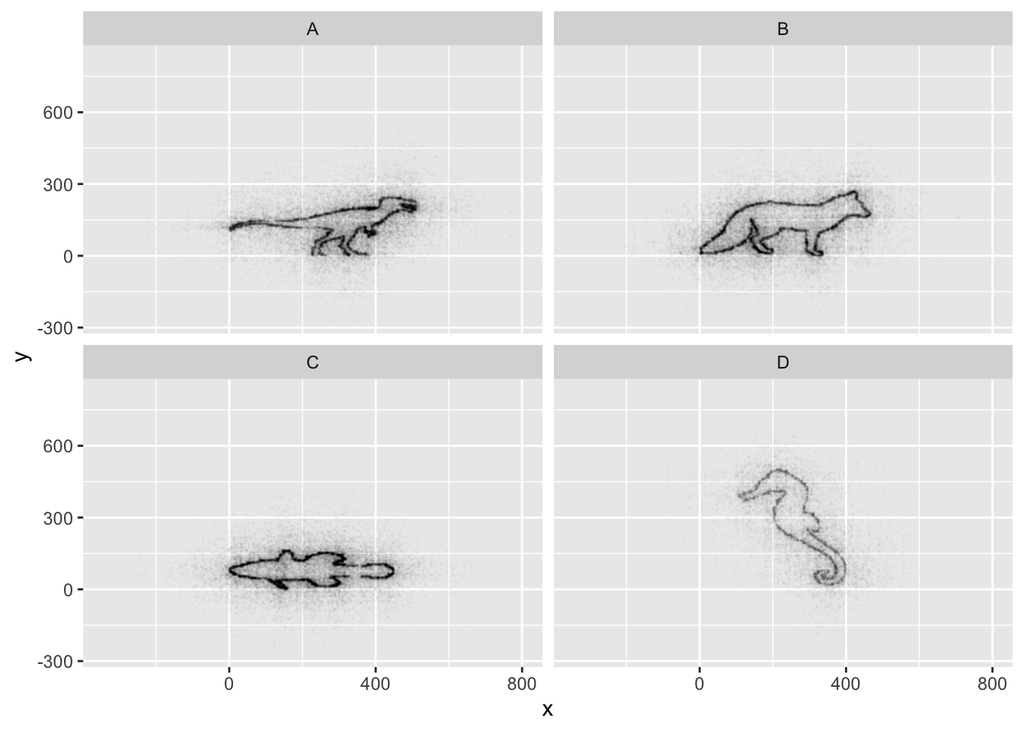

```r
#### Visualize ----
myPlot = fullData %>%
  ggplot(aes(x = x, y = y)) +
  facet_wrap(~Group) +
  geom_point(size = 0.1,
             alpha = 0.01)
myPlot
```

```r
ggsave("plots/clearPlot.jpg",
       myPlot,
       width = 5, height = 5,
       units = "in", dpi = 300)
```

This challenge was inspired by Trevor Branch’s [Twitter post](https://twitter.com/TrevorABranch/status/1227493205337182209), and adapted by me for a lesson on faceting.